# R Notebook

1.(10 pts) Scrape the data from the webpage and extract the following fields: Country, < $1.90, < $3.20, < $5.50, Year and Continent. Prepare the data for analysis and ensure that the columns have meaningful names.

```r
library(tidyverse)
library(rvest)
url <- "https://en.wikipedia.org/wiki/List_of_countries_by_percentage_of_population_living_in_poverty"

wiki <- read_html(url) %>% html_table(fill= NULL)
wiki #We can see the scraped data
```

```
## [[1]]
## # A tibble: 1 x 2
##   X1    X2
##   <lgl> <chr>
## 1 NA    This section needs to be updated. Please update this article to reflect…
##
## [[2]]
## # A tibble: 196 x 6
##    Country             `< $1.90[1]` `< $3.20[5]` `< $5.50[6]` Year  Continent
##    <chr>               <chr>        <chr>        <chr>        <chr> <chr>
##  1 Afghanistan         N/A          N/A          N/A          N/A   Asia
##  2 Albania             1.3%         8.2%         33.8%        2017  Europe
##  3 Algeria             0.4%         3.7%         28.6%        2011  Africa
##  4 Andorra             N/A          N/A          N/A          N/A   Europe
##  5 Angola              51.8%        73.2%        89.3%        2018  Africa
##  6 Antigua and Barbuda N/A          N/A          N/A          N/A   North Ameri…
##  7 Argentina           1.3%         1.3%         12.2%        2018  South Ameri…
##  8 Armenia             1.4%         9.4%         42.5%        2018  Asia
##  9 Australia           0.5%         0.7%         0.7%         2014  Oceania
## 10 Austria             0.3%         0.4%         0.7%         2017  Europe
## # … with 186 more rows
##
## [[3]]
## # A tibble: 209 x 8
##    Country        `WorldBank[10]` Year  `CIA[11]` Year  Other Year   Continent
##    <chr>          <chr>           <chr> <chr>     <chr> <chr> <chr>  <chr>
##  1 Afghanistan    54.5%           2016  54.5%     2017  N/A   N/A    Asia
##  2 Albania        14.3%           2012  14.3%     2012  N/A   N/A    Europe
##  3 Algeria        5.5%            2011  23.0%     2006  N/A   N/A    Africa
##  4 Andorra        N/A             N/A   N/A       N/A   N/A   N/A    Europe
##  5 Angola         36.6%           2008  36.6%     2008  N/A   N/A    Africa
##  6 Anguilla       N/A             N/A   23.0%     2002  N/A   N/A    North Amer…
##  7 Antigua and B… N/A             N/A   N/A       N/A   N/A   N/A    North Amer…
##  8 Argentina      25.7%           2017  25.7%     2017  42.0% 2021[… South Amer…
##  9 Armenia        25.7%           2017  32.0%     2013  N/A   N/A    Asia
## 10 Australia      N/A             N/A   N/A       N/A   N/A   N/A    Oceania
## # … with 199 more rows
##
## [[4]]
## # A tibble: 20 x 8
```

[output cut: 113 more lines]

[output not shown]

```r
poverty_table <- wiki[[2]] #This is the table of choice
glimpse(poverty_table) #Initially all the data types are in character format
```

```
## Rows: 196
## Columns: 6
## $ Country      <chr> "Afghanistan", "Albania", "Algeria", "Andorra", "Angola",…
## $ `< $1.90[1]` <chr> "N/A", "1.3%", "0.4%", "N/A", "51.8%", "N/A", "1.3%", "1.…
## $ `< $3.20[5]` <chr> "N/A", "8.2%", "3.7%", "N/A", "73.2%", "N/A", "1.3%", "9.…
## $ `< $5.50[6]` <chr> "N/A", "33.8%", "28.6%", "N/A", "89.3%", "N/A", "12.2%", …
## $ Year         <chr> "N/A", "2017", "2011", "N/A", "2018", "N/A", "2018", "201…
## $ Continent    <chr> "Asia", "Europe", "Africa", "Europe", "Africa", "North Am…
```

```r
poverty_table %>%names()
```

```
## [1] "Country"    "< $1.90[1]" "< $3.20[5]" "< $5.50[6]" "Year"
## [6] "Continent"
```

```r
poverty_table <- poverty_table %>% as_tibble (poverty_table) %>%
  rename("population_under_1.90" ="< $1.90[1]",
                        "population_under_3.20" = "< $3.20[5]",
                        "population_under_5.50"= "< $5.50[6]")
poverty_table <- as.data.frame(poverty_table) #Converting to data frame
```

2.(10 pts) Calculate the mean and the standard deviation of the percent of the population living under $5.50 per day for each continent. Perform a comparative analysis (i.e. explanation) of the data from each continent.

```r
#removing % symbol before converting to numeric
poverty_table$population_under_1.90 <- gsub("%", "", poverty_table$population_under_1.90)
poverty_table$population_under_3.20 <- gsub("%", "", poverty_table$population_under_3.20)
poverty_table$population_under_5.50 <- gsub("%", "", poverty_table$population_under_5.50)

poverty_table$population_under_1.90 <- as.numeric(poverty_table$population_under_1.90) #conversion to numeric
poverty_table$population_under_1.90 <- poverty_table$population_under_1.90/100 #conversion to percentage

poverty_table$population_under_3.20 <- as.numeric(poverty_table$population_under_3.20) #conversion to numeric
poverty_table$population_under_3.20 <- poverty_table$population_under_3.20/100 #conversion to percentage

poverty_table$population_under_5.50 <- as.numeric(poverty_table$population_under_5.50) #conversion to numeric
poverty_table$population_under_5.50 <-poverty_table$population_under_5.50/100 #conversion to percentage

str(poverty_table)
```

```
## 'data.frame':    196 obs. of  6 variables:
##  $ Country              : chr  "Afghanistan" "Albania" "Algeria" "Andorra" ...
##  $ population_under_1.90: num  NA 0.013 0.004 NA 0.518 NA 0.013 0.014 0.005 0.003 ...
##  $ population_under_3.20: num  NA 0.082 0.037 NA 0.732 NA 0.013 0.094 0.007 0.004 ...
##  $ population_under_5.50: num  NA 0.338 0.286 NA 0.893 NA 0.122 0.425 0.007 0.007 ...
##  $ Year                 : chr  "N/A" "2017" "2011" "N/A" ...
##  $ Continent            : chr  "Asia" "Europe" "Africa" "Europe" ...
```

```r
View(poverty_table)


#Finding mean and standard deviation for each continent
population_calc <- poverty_table %>%
  group_by(Continent) %>%
  summarise (mean(population_under_5.50, na.rm= TRUE), sd(population_under_5.50, na.rm= TRUE)) %>%
  rename("Mean" = "mean(population_under_5.50, na.rm = TRUE)",
         "Standard_Deviation" = "sd(population_under_5.50, na.rm = TRUE)")

population_calc
```

| Continent | Mean | Standard_Deviation |
| --- | --- | --- |
| Africa | 0.75022000 | 0.242629666 |
| Asia | 0.40434286 | 0.296806329 |
| Asia, Europe | 0.02650000 | 0.004949747 |
| Europe | 0.05604878 | 0.096826637 |
| North America | 0.28878571 | 0.222551007 |
| Oceania | 0.56922222 | 0.275577928 |
| South America | 0.25623077 | 0.166254902 |

```r
poverty_table %>%
  count(Continent)
```

| Continent | n |
| --- | --- |
| Africa | 54 |
| Asia | 46 |
| Asia, Europe | 2 |
| Europe | 46 |
| North America | 22 |
| Oceania | 13 |
| South America | 13 |

Summary: Africa has the most number of countries and comparitively the highest percentage of people below the given poverty line in all 3 cases,and thus it has a higher mean. Congo, Democratic Republic of Africa has a very high percentage of population below $1.90, $3.20 and ultimately a high percentage under 5.50 whereas the lowest percentage in Africa is in Seychelles (others have NA values).

North and South America on the other hand are somewhat in between. Their total countries are less than Asia and Africa alone, plus the country is more developed and hence the mean value is 0.28 and 0.25 respectively with a standard deviation of 0.22 and 0.166.

3.(5 pts) What are the 10 countries with the highest percentage of the population having an income of less than $5.50 per day? Using a suitable chart, display the country name, the percentage and color-code by the Continent. Summarize your findings.

```r
# Arranging the population_under_5.50 table in descending while getting rid of NA values

desc <- poverty_table %>%
  arrange(population_under_5.50) %>%
  select(Country, population_under_5.50, Continent) %>%
  na.omit()

#To find the 10 countries with the highest percentage of the population having an income of less than $5.50 per day
top10 <- tail(desc, 10)
top10
```

|  | Country | population_under_5.50 | Continent |
| --- | --- | --- | --- |
| 155 | Tanzania | 0.931 | Africa |
| 156 | Guinea-Bissau | 0.934 | Africa |
| 157 | Niger | 0.934 | Africa |
| 158 | East Timor | 0.940 | Asia |
| 159 | Mali | 0.949 | Africa |
| 160 | Uzbekistan | 0.964 | Asia |
| 161 | Malawi | 0.967 | Africa |
| 162 | Burundi | 0.968 | Africa |
| 163 | Madagascar | 0.973 | Africa |
| 164 | Congo, Democratic Republic of the | 0.977 | Africa |

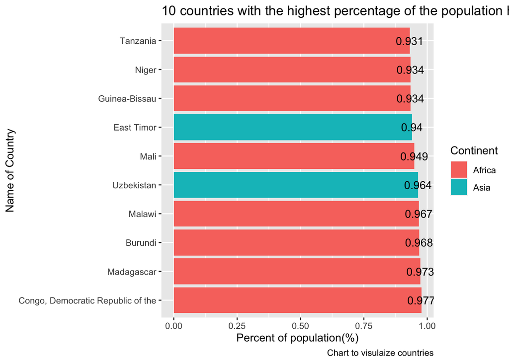

```r
#Histogram to display the country name, the percentage color-coded by the Continent
ggplot(data= top10, aes(x= reorder(Country, -population_under_5.50), y= population_under_5.50, fill= Continent))+
  geom_histogram(stat= "identity", bins  = 30) +
  #scale_x_discrete(guide = guide_axis(n.dodge=3))+
  coord_flip()+
   #theme(axis.text.x = element_text(angle= 90, hjust=-0))
  geom_text(stat= "identity", aes(label = population_under_5.50))+
  labs(title= "10 countries with the highest percentage of the population having an income of less than $5.50 per day",
        caption = "Chart to visulaize countries",
        fill= "Continent") +
   xlab("Name of Country") + ylab("Percent of population(%)")
```

Summary: The countries with the highest percentage of the population having an income of less than $5.50 per day include Tanzania as the 10th one with a proportion of 93.1% and Congo, Democratic Republic of the..with proportion of 97.7%. 8 out of the 10 countries excluding East Timor and Uzbekistan are African countries which again concludes, like the previous question that Africa is the continent with the majority of population below poverty line followed by Asia